# Changes in peatland soil fauna biomass alter food web structure and function under warming and hydrological changes

### Supplemental Table 3.9

Shapiro-Wilk and Levene’s Tests constructed to test whether phenol oxidase and peroxidase activity conform to the assumptions of normality and homodescacity.

```r
enzymes_df1 <- as.data.frame(matrix(data = c(
  "Phenol Oxidase Concentration",
  "Shapiro-Wilk Test",
  paste0("W = ",
         format(round(shapiro_test(residuals(phenox_lm2))$statistic, 3),
         nsmall = 3)),
  paste0("p = ",
         format(round(shapiro_test(residuals(phenox_lm2))$p.value, 3),
         nsmasll = 3)),
  "Phenol Oxidase Concentration",
  "Levene's Test",
  paste0("F", sub_digits(
    levene_test(Phenox ~ (moisture_tx * temp_tx * destructive_time),
              data = soil_T1uT2)$df1), "\u02CC",
  sub_digits(
    levene_test(Phenox ~ (moisture_tx * temp_tx * destructive_time),
              data = soil_T1uT2)$df2), " = ",
  format(round(levene_test(Phenox ~
                             (moisture_tx * temp_tx * destructive_time),
              data = soil_T1uT2)$statistic, 3), nsmall = 3)),
  paste0("p = ", format(round(levene_test(Phenox ~
                             (moisture_tx * temp_tx * destructive_time),
              data = soil_T1uT2)$p, 3), nsmall = 3)),
  "Peroxidase Concentration",
  "Shapiro-Wilk Test",
  paste0("W = ",
         format(round(shapiro_test(residuals(perox_lm2))$statistic, 3),
         nsmall = 3)),
  paste0("p = ",
         format(round(shapiro_test(residuals(perox_lm2))$p.value, 3),
         nsmasll = 3)),
  "Peroxidase Concentration",
  "Levene's Test",
  paste0("F", sub_digits(
    levene_test(Perox ~ (moisture_tx * temp_tx * destructive_time),
              data = soil_T1uT2)$df1), "\u02CC",
  sub_digits(
    levene_test(Perox ~ (moisture_tx * temp_tx * destructive_time),
              data = soil_T1uT2)$df2), " = ",
  format(round(levene_test(Perox ~
                             (moisture_tx * temp_tx * destructive_time),
              data = soil_T1uT2)$statistic, 3), nsmall = 3)),
  paste0("p = ", format(round(levene_test(Perox ~
                             (moisture_tx * temp_tx * destructive_time),
              data = soil_T1uT2)$p, 3), nsmall = 3))
  ), ncol = 4, byrow = T))

colnames(enzymes_df1) <- c("Parameter", "Test", "Statistic", "P-Value")

knitr::kable(enzymes_df1, linesep = "\\hline")
```

| Parameter | Test | Statistic | P-Value |
| --- | --- | --- | --- |
| Phenol Oxidase Concentration | Shapiro-Wilk Test | W = 0.959 | p = 0.182 |
| Phenol Oxidase Concentration | Levene’s Test | F₇ˌ₃₀ = 2.099 | p = 0.075 |
| Peroxidase Concentration | Shapiro-Wilk Test | W = 0.946 | p = 0.074 |
| Peroxidase Concentration | Levene’s Test | F₇ˌ₂₉ = 0.584 | p = 0.763 |

```r
phenox_aov2 <- Anova(phenox_lm2, type = 'III')
```

Mean phenol oxidase activity (Figure 3.3A) was not significantly affected by soil moisture treatments (F₁ˌ₃₂ = 0.760, p = 0.390), but was strongly driven by temperature conditions (F₁ˌ₃₂ = 16.455, p = 0.000). Mean phenol oxidase activity increased in mesocosms assigned to 20 °C vs. 12 °C conditions. Destructive sampling treatments also significantly affected phenol oxidase activity (F₁ˌ₃₂ = 5.398, p = 0.027) and was greater at T<sub>2</sub> vs. T<sub>1</sub>. This was driven by a significant temperature by destructive sampling time interaction (F₁ˌ₃₂ = 9.001, p = 0.005), which suggests that phenol oxidase activity decreased in mesocosms assigned to 20 °C from T<sub>1</sub> to T<sub>2</sub> following a three-week return to initial 12 °C conditions. Block effects constructed corresponding to differences in total abundance by original sampling location (F₁ˌ₃₂ = 1.159, p = 0.290) did not have a significant effect on phenol oxidase activity. There were no other significant interaction effects between soil moisture, temperature, and destructive sampling time (Appendix E). Overall, mean phenol oxidase activity (± SE) was greatest (199 ± 24 μmol substrate per g soil per hour) in mesocosms assigned to 20 °C field-moist conditions, sampled at T<sub>1</sub> and was least (90 ± 19 μmol substrate per g soil per hour) in those assigned to 12 °C saturated conditions, sampled at T<sub>1</sub> (see Appendix D). Estimates of effect size based on a linear model are given in Appendix F.

### Supplemental Table 3.10

Phenol oxidase activity ANOVA results.

```r
phenox_aov_tbl <- as.data.frame(matrix(data = c(
  "Intercept",
  paste0("F", sub_digits(phenox_aov2["(Intercept)", "Df"]),
         "\u02CC", sub_digits(phenox_aov2["Residuals", "Df"]),
         " = ", format(round(phenox_aov2["(Intercept)", "F value"], 3),
                       nsmall = 3)),
  paste0("p = ", format(round(phenox_aov2["(Intercept)", "Pr(>F)"], 3),
                       nsmall = 3)),
  "Soil Moisture Treatment",
  paste0("F", sub_digits(phenox_aov2["moisture_tx", "Df"]),
         "\u02CC", sub_digits(phenox_aov2["Residuals", "Df"]),
         " = ", format(round(phenox_aov2["moisture_tx", "F value"], 3),
                       nsmall = 3)),
  paste0("p = ", format(round(phenox_aov2["moisture_tx", "Pr(>F)"], 3),
                       nsmall = 3)),
  "Temperature Treatment",
  paste0("F", sub_digits(phenox_aov2["temp_tx", "Df"]),
         "\u02CC", sub_digits(phenox_aov2["Residuals", "Df"]),
         " = ", format(round(phenox_aov2["temp_tx", "F value"], 3),
                       nsmall = 3)),
  paste0("p = ", format(round(phenox_aov2["temp_tx", "Pr(>F)"], 3),
                       nsmall = 3)),
  "Destructive Sampling Treatment",
  paste0("F", sub_digits(phenox_aov2["destructive_time", "Df"]),
         "\u02CC", sub_digits(phenox_aov2["Residuals", "Df"]),
         " = ", format(round(phenox_aov2["destructive_time", "F value"],
                             3),
                       nsmall = 3)),
  paste0("p = ", format(round(phenox_aov2["destructive_time", "Pr(>F)"],
                              3),
                       nsmall = 3)),
  "Block Effect",
  paste0("F", sub_digits(phenox_aov2["block_effect", "Df"]),
         "\u02CC", sub_digits(phenox_aov2["Residuals", "Df"]),
         " = ", format(round(phenox_aov2["block_effect", "F value"], 3),
                       nsmall = 3)),
  paste0("p = ", format(round(phenox_aov2["block_effect", "Pr(>F)"], 3),
                       nsmall = 3)),
  "Temperature x Destructive Sampling Interaction",
  paste0("F", sub_digits(phenox_aov2["temp_tx:destructive_time", "Df"]),
         "\u02CC", sub_digits(phenox_aov2["Residuals", "Df"]),
         " = ", format(round(phenox_aov2["temp_tx:destructive_time",
                                         "F value"],
                             3),
                       nsmall = 3)),
  paste0("p = ", format(round(phenox_aov2["temp_tx:destructive_time",
                                          "Pr(>F)"],
                              3),
                       nsmall = 3))
), ncol = 3, byrow = T))

colnames(phenox_aov_tbl) <- c("Parameter", "Statistic", "P-Value")

knitr::kable(phenox_aov_tbl)
```

| Parameter | Statistic | P-Value |
| --- | --- | --- |
| Intercept | F₁ˌ₃₂ = 55.547 | p = 0.000 |
| Soil Moisture Treatment | F₁ˌ₃₂ = 0.760 | p = 0.390 |
| Temperature Treatment | F₁ˌ₃₂ = 16.455 | p = 0.000 |
| Destructive Sampling Treatment | F₁ˌ₃₂ = 5.398 | p = 0.027 |
| Block Effect | F₁ˌ₃₂ = 1.159 | p = 0.290 |
| Temperature x Destructive Sampling Interaction | F₁ˌ₃₂ = 9.001 | p = 0.005 |

```r
perox_aov2 <- Anova(perox_lm2, type = 'III')
```

Mean peroxidase activity (Figure 3.3B) was not influenced by soil moisture (F₁ˌ₃₁ = 0.009, p = 0.925), but was significantly affected by temperature (F₁ˌ₃₁ = 6.954, p = 0.013) and increased at 20 °C vs 12 °C. Mean peroxidase activity was also significantly affected by destructive sampling treatments (F₁ˌ₃₁ = 20.949, p = 0.000) and was greater in mesocosms sampled at T<sub>2</sub> vs. T<sub>1</sub>. This was driven by a significant temperature by destructive sampling time interaction (F₁ˌ₃₁ = 5.235, p = 0.029), which suggests that peroxidase activity also decreased in mesocosms assigned to 20 °C from T<sub>1</sub> to T<sub>2</sub> following a three-week return to initial 12 °C conditions. Block effects also significantly influenced mean peroxidase activity (F₁ˌ₃₁ = 6.091, p = 0.019); peroxidase activity tended to decrease in blocks characterized by especially high soil fauna abundances. There were no other significant interaction effects between soil moisture, temperature, and destructive sampling time (Appendix E). Mean peroxidase concentration (± SE) under each treatment is presented in Appendix D. Estimates of effect size based on a linear model are given in Appendix F.

### Supplemental Table 3.11

Peroxidase activity ANOVA results.

```r
perox_aov_tbl <- as.data.frame(matrix(data = c(
  "Intercept",
  paste0("F", sub_digits(perox_aov2["(Intercept)", "Df"]),
         "\u02CC", sub_digits(perox_aov2["Residuals", "Df"]),
         " = ", format(round(perox_aov2["(Intercept)", "F value"], 3),
                       nsmall = 3)),
  paste0("p = ", format(round(perox_aov2["(Intercept)", "Pr(>F)"], 3),
                       nsmall = 3)),
  "Soil Moisture Treatment",
  paste0("F", sub_digits(perox_aov2["moisture_tx", "Df"]),
         "\u02CC", sub_digits(perox_aov2["Residuals", "Df"]),
         " = ", format(round(perox_aov2["moisture_tx", "F value"], 3),
                       nsmall = 3)),
  paste0("p = ", format(round(perox_aov2["moisture_tx", "Pr(>F)"], 3),
                       nsmall = 3)),
  "Temperature Treatment",
  paste0("F", sub_digits(perox_aov2["temp_tx", "Df"]),
         "\u02CC", sub_digits(perox_aov2["Residuals", "Df"]),
         " = ", format(round(perox_aov2["temp_tx", "F value"], 3),
                       nsmall = 3)),
  paste0("p = ", format(round(perox_aov2["temp_tx", "Pr(>F)"], 3),
                       nsmall = 3)),
  "Destructive Sampling Treatment",
  paste0("F", sub_digits(perox_aov2["destructive_time", "Df"]),
         "\u02CC", sub_digits(perox_aov2["Residuals", "Df"]),
         " = ", format(round(perox_aov2["destructive_time", "F value"],
                             3),
                       nsmall = 3)),
  paste0("p = ", format(round(perox_aov2["destructive_time", "Pr(>F)"],
                              3),
                       nsmall = 3)),
  "Block Effect",
  paste0("F", sub_digits(perox_aov2["block_effect", "Df"]),
         "\u02CC", sub_digits(perox_aov2["Residuals", "Df"]),
         " = ", format(round(perox_aov2["block_effect", "F value"], 3),
                       nsmall = 3)),
  paste0("p = ", format(round(perox_aov2["block_effect", "Pr(>F)"], 3),
                       nsmall = 3)),
  "Temperature x Destructive Sampling Interaction",
  paste0("F", sub_digits(perox_aov2["temp_tx:destructive_time", "Df"]),
         "\u02CC", sub_digits(perox_aov2["Residuals", "Df"]),
         " = ", format(round(perox_aov2["temp_tx:destructive_time",
                                         "F value"],
                             3),
                       nsmall = 3)),
  paste0("p = ", format(round(perox_aov2["temp_tx:destructive_time",
                                          "Pr(>F)"],
                              3),
                       nsmall = 3))
), ncol = 3, byrow = T))

colnames(perox_aov_tbl) <- c("Parameter", "Statistic", "P-Value")

knitr::kable(perox_aov_tbl)
```

| Parameter | Statistic | P-Value |
| --- | --- | --- |
| Intercept | F₁ˌ₃₁ = 42.085 | p = 0.000 |
| Soil Moisture Treatment | F₁ˌ₃₁ = 0.009 | p = 0.925 |
| Temperature Treatment | F₁ˌ₃₁ = 6.954 | p = 0.013 |
| Destructive Sampling Treatment | F₁ˌ₃₁ = 20.949 | p = 0.000 |
| Block Effect | F₁ˌ₃₁ = 6.091 | p = 0.019 |
| Temperature x Destructive Sampling Interaction | F₁ˌ₃₁ = 5.235 | p = 0.029 |

## 3.5 Soil Fauna Abundance and Biomass

### Figure 3.4

Boxplots of mean fauna abundance (A) and biomass (B).

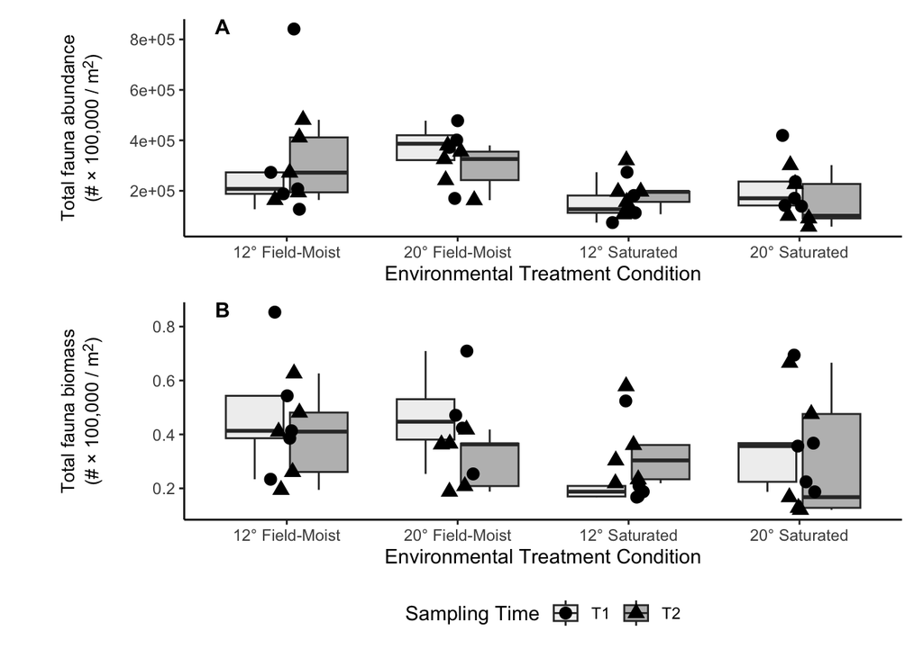

Mesocosms were assessed across experimental treatments of temperature (12 °C, 20 °C) and soil moisture (field-moist, saturated) destructively sampled after three-weeks (T<sub>1</sub>) or following three-week recovery period (T<sub>2</sub>).

```r
abundance_T1uT2 <- abundance_data %>% filter(!destructive_time == "T0")
biomass_T1uT2 <- biomass_data %>% filter(!destructive_time == "T0")

abundance_T1uT2$tx <- interaction(abundance_T1uT2$temp_tx,
                                  abundance_T1uT2$moisture_tx)

abundance_T1uT2 <- abundance_T1uT2 %>%
  mutate(tx = fct_recode(tx,
    "12\u00B0 Field-Moist" = "12.Ambient",
    "20\u00B0 Field-Moist" = "20.Ambient",
    "12\u00B0 Saturated"   = "12.High",
    "20\u00B0 Saturated"   = "20.High"
  ))

biomass_T1uT2$tx <- interaction(biomass_T1uT2$temp_tx,
                                  biomass_T1uT2$moisture_tx)

biomass_T1uT2 <- biomass_T1uT2 %>%
  mutate(tx = fct_recode(tx,
    "12\u00B0 Field-Moist" = "12.Ambient",
    "20\u00B0 Field-Moist" = "20.Ambient",
    "12\u00B0 Saturated"   = "12.High",
    "20\u00B0 Saturated"   = "20.High"
  ))

ylab_abundance <- "<span style='font-size:10pt'>Total fauna abundance<br>(# × 100,000 / m<sup>2</sup>)</span>"
ylab_biomass  <- "<span style='font-size:10pt'>Total fauna biomass<br>(# × 100,000 / m<sup>2</sup>)</span>"

left_pad <- theme(plot.margin = margin(5, 6, 5, 70))

abundance_plot <-
  ggplot(abundance_T1uT2,
         aes(x=tx,
             y=total_ab_standardized, fill = as.factor(destructive_time))) +
  geom_boxplot(outlier.shape=NA) + #avoid plotting outliers twice
  geom_jitter(aes(pch = as.factor(destructive_time)),
              position=position_jitter(width=.1, height=0), size = 3) +
  theme(panel.grid.major = element_blank(),
        panel.grid.minor = element_blank(),
        panel.background = element_blank(),
        axis.line = element_line(colour = "black"),
        axis.title.y = element_textbox_simple(orientation="left-rotated",
                                              halign = 0.5,
                                              margin = margin(b = 15))) +
  scale_fill_brewer(palette = "Greys") +
  xlab("Environmental Treatment Condition") +
  ylab(ylab_abundance) +
  labs(fill = "Sampling Time", pch = "Sampling Time")

biomass_plot <- ggplot(biomass_T1uT2, aes(x=tx,
                                          y=total_biomass,
                                          fill = as.factor(destructive_time))) +
  geom_boxplot(outlier.shape=NA) + #avoid plotting outliers twice
  geom_jitter(aes(pch = as.factor(destructive_time)),
              position=position_jitter(width=.1, height=0), size = 3) +
  theme(panel.grid.major = element_blank(),
        panel.grid.minor = element_blank(),
        panel.background = element_blank(),
        axis.line = element_line(colour = "black"),
        axis.title.y = element_textbox_simple(orientation="left-rotated",
                                              halign = 0.5,
                                              margin = margin(b = 15))) +
  scale_fill_brewer(palette = "Greys") +
  xlab("Environmental Treatment Condition") +
  ylab(ylab_biomass) +
  labs(fill = "Sampling Time", pch = "Sampling Time")

g1 <- place_tag(abundance_plot, "A", x_left = 0.58)
g2 <- place_tag(biomass_plot,            "B", x_left = 0.58)

(g1 / g2) +
  plot_layout(ncol = 1, guides = "collect") &
  theme(legend.position = "bottom")
```

```r
total_ab_lm <- lm(total_ab_standardized ~
                          moisture_tx * temp_tx * destructive_time +
                          moisture_tx * temp_tx +
                          moisture_tx * destructive_time +
                          temp_tx * destructive_time +
                          moisture_tx +
                          temp_tx +
                          destructive_time +
                          block_effect,
                     data = abundance_T1uT2)

total_ab_lm2 <- lm(total_ab_standardized ~
                    moisture_tx +
                    temp_tx +
                    destructive_time +
                    block_effect,
                data = abundance_T1uT2)

micro_ab_lm <- lm(total_micro_ab_standardized ~
                          moisture_tx * temp_tx * destructive_time +
                          moisture_tx * temp_tx +
                          moisture_tx * destructive_time +
                          temp_tx * destructive_time +
                          moisture_tx +
                          temp_tx +
                          destructive_time +
                          block_effect,
                     data = abundance_T1uT2)

micro_ab_lm2 <- lm(total_micro_ab_standardized ~
                    moisture_tx +
                    temp_tx +
                    destructive_time +
                    block_effect,
                data = abundance_T1uT2)

meso_ab_lm <- lm(log(total_meso_ab_standardized) ~
                        moisture_tx * temp_tx * destructive_time +
                        moisture_tx * temp_tx +
                        moisture_tx * destructive_time +
                        temp_tx * destructive_time +
                        moisture_tx +
                        temp_tx +
                        destructive_time +
                        block_effect,
                    data = abundance_T1uT2)

meso_ab_lm2 <- lm(log(total_meso_ab_standardized) ~
                    temp_tx * destructive_time +
                    moisture_tx +
                    temp_tx +
                    destructive_time +
                    block_effect,
               data = abundance_T1uT2)

total_biom_lm <- lm(total_biomass ~
                            moisture_tx * temp_tx * destructive_time +
                            moisture_tx * temp_tx +
                            moisture_tx * destructive_time +
                            temp_tx * destructive_time +
                            moisture_tx +
                            temp_tx +
                            destructive_time +
                            block_effect,
                       data = biomass_T1uT2)

total_biom_lm2 <- lm(total_biomass ~
                      moisture_tx * destructive_time +
                      moisture_tx +
                      temp_tx +
                      destructive_time +
                      block_effect,
                  data = biomass_T1uT2)

micro_biom_lm <- lm(micro_biomass ~
                          moisture_tx * temp_tx * destructive_time +
                          moisture_tx * temp_tx +
                          moisture_tx * destructive_time +
                          temp_tx * destructive_time +
                          moisture_tx +
                          temp_tx +
                          destructive_time +
                          block_effect,
                       data = biomass_T1uT2)

micro_biom_lm2 <- lm(micro_biomass ~
                      moisture_tx +
                      temp_tx +
                      destructive_time +
                      block_effect,
                  data = biomass_T1uT2)

meso_biom_lm <- lm(meso_biomass ~
                          moisture_tx * temp_tx * destructive_time +
                          moisture_tx * temp_tx +
                          moisture_tx * destructive_time +
                          temp_tx * destructive_time +
                          moisture_tx +
                          temp_tx +
                          destructive_time +
                          block_effect,
                      data = biomass_T1uT2)

meso_biom_lm2 <- lm(meso_biomass ~
                      moisture_tx * destructive_time +
                      moisture_tx +
                      temp_tx +
                      destructive_time +
                      block_effect,
                 data = biomass_T1uT2)
```

Mean total soil fauna abundance (Shapiro-Wilk’s test: W = 0.980, p = 0.701; Levene’s test: F₇ˌ₃₁ = 0.435, p = 0.872) and total soil microfauna abundance (Shapiro-Wilk’s test: W = 0.980, p = 0.704; Levene’s test: F₇ˌ₃₁ = 0.955, p = 0.480) each satisfied the assumptions of normality and homogeneity of variance, as per a Shapiro-Wilk’s test and Levene’s test. Total soil mesofauna abundance was transformed on natural log, (ln) scale to conform to the assumption of normality (Shapiro-Wilk’s test: W = 0.976, p = 0.564; Levene’s test: F<sub>7,31</sub> = 0.389, p = 0.901). Total biomass (Shapiro-Wilk’s test: W = 0.953, p = 0.107; Levene’s test: F<sub>7,31</sub> = 0.317, p = 0.940), total soil microfauna biomass (Shapiro-Wilk’s test: W = 0.980, p = 0.704; Levene’s test: F<sub>7,31</sub> = 0.955, p = 0.480), and total soil mesofauna biomass (Shapiro-Wilk’s test: W = 0.953, p = 0.105; Levene’s test: F<sub>7,31</sub> = 0.313, p = 0.943) each met the assumptions of normality and homogeneity of variance.